# KIN 482E Final Assignment: Exploring the Accuracy of EA Sports FIFA's Ratings

## Source of File:

https://sports-statistics.com/sports-data/fifa-2022-dataset-csvs/

## Overview:

The goal of this project is to test the accuracy of the ratings in EA Sport's popular soccer/football video game "FIFA 22". Every year EA Sports releases a new version of this game and one of the most debated topics is always people complaining about ratings, whether people are rated too highly or too low. My goal is to take this database of player ratings, perform analysis and compare to what happened in real life. I will be comparing the average squad rating for each team according to EA Sports in the Top 5 Leagues in Europe (England, Germany, Spain, Italy, France) and then seeing how these squad ratings compared with the final table/standings of each league in real life for that year. This will give me an idea as to how accurate EA Sports is at rating players and also tell me which league they are the most/least accurate at predicting

## Rationale

The reason why I chose to do my project on this topic is because I have played FIFA games for almost all my life and I always wondered how accurate the ratings really were but before this year I never really knew how to analyze this. I want to know how accurate their predictions are for each league and which league they are most accurate at rating.

## Reading-In, Processing and Analyzing Data

In the steps below I first imported the necessary packages for the project, and then used pandas to read in the csv file.

```python
import numpy as np
import seaborn as sns
import matplotlib.pyplot as plt
import pandas as pd

df = pd.read_csv('players_22.csv')
df
```

|  | sofifa_id | player_url | short_name | long_name | player_positions | overall | potential | value_eur | wage_eur | age | ... | lcb | cb | rcb | rb | gk | player_face_url | club_logo_url | club_flag_url | nation_logo_url | nation_flag_url |
| --- | --- | --- | --- | --- | --- | --- | --- | --- | --- | --- | --- | --- | --- | --- | --- | --- | --- | --- | --- | --- | --- |
| 0 | 158023 | https://sofifa.com/player/158023/lionel-messi/... | L. Messi | Lionel Andrés Messi Cuccittini | RW, ST, CF | 93 | 93 | 78000000.0 | 320000.0 | 34 | ... | 50+3 | 50+3 | 50+3 | 61+3 | 19+3 | https://cdn.sofifa.net/players/158/023/22_120.png | https://cdn.sofifa.net/teams/73/60.png | https://cdn.sofifa.net/flags/fr.png | https://cdn.sofifa.net/teams/1369/60.png | https://cdn.sofifa.net/flags/ar.png |
| 1 | 188545 | https://sofifa.com/player/188545/robert-lewand... | R. Lewandowski | Robert Lewandowski | ST | 92 | 92 | 119500000.0 | 270000.0 | 32 | ... | 60+3 | 60+3 | 60+3 | 61+3 | 19+3 | https://cdn.sofifa.net/players/188/545/22_120.png | https://cdn.sofifa.net/teams/21/60.png | https://cdn.sofifa.net/flags/de.png | https://cdn.sofifa.net/teams/1353/60.png | https://cdn.sofifa.net/flags/pl.png |
| 2 | 20801 | https://sofifa.com/player/20801/c-ronaldo-dos-... | Cristiano Ronaldo | Cristiano Ronaldo dos Santos Aveiro | ST, LW | 91 | 91 | 45000000.0 | 270000.0 | 36 | ... | 53+3 | 53+3 | 53+3 | 60+3 | 20+3 | https://cdn.sofifa.net/players/020/801/22_120.png | https://cdn.sofifa.net/teams/11/60.png | https://cdn.sofifa.net/flags/gb-eng.png | https://cdn.sofifa.net/teams/1354/60.png | https://cdn.sofifa.net/flags/pt.png |
| 3 | 190871 | https://sofifa.com/player/190871/neymar-da-sil... | Neymar Jr | Neymar da Silva Santos Júnior | LW, CAM | 91 | 91 | 129000000.0 | 270000.0 | 29 | ... | 50+3 | 50+3 | 50+3 | 62+3 | 20+3 | https://cdn.sofifa.net/players/190/871/22_120.png | https://cdn.sofifa.net/teams/73/60.png | https://cdn.sofifa.net/flags/fr.png | NaN | https://cdn.sofifa.net/flags/br.png |
| 4 | 192985 | https://sofifa.com/player/192985/kevin-de-bruy... | K. De Bruyne | Kevin De Bruyne | CM, CAM | 91 | 91 | 125500000.0 | 350000.0 | 30 | ... | 69+3 | 69+3 | 69+3 | 75+3 | 21+3 | https://cdn.sofifa.net/players/192/985/22_120.png | https://cdn.sofifa.net/teams/10/60.png | https://cdn.sofifa.net/flags/gb-eng.png | https://cdn.sofifa.net/teams/1325/60.png | https://cdn.sofifa.net/flags/be.png |
| ... | ... | ... | ... | ... | ... | ... | ... | ... | ... | ... | ... | ... | ... | ... | ... | ... | ... | ... | ... | ... | ... |
| 19234 | 261962 | https://sofifa.com/player/261962/defu-song/220002 | Song Defu | 宋德福 | CDM | 47 | 52 | 70000.0 | 1000.0 | 22 | ... | 46+2 | 46+2 | 46+2 | 48+2 | 15+2 | https://cdn.sofifa.net/players/261/962/22_120.png | https://cdn.sofifa.net/teams/112541/60.png | https://cdn.sofifa.net/flags/cn.png | NaN | https://cdn.sofifa.net/flags/cn.png |
| 19235 | 262040 | https://sofifa.com/player/262040/caoimhin-port... | C. Porter | Caoimhin Porter | CM | 47 | 59 | 110000.0 | 500.0 | 19 | ... | 44+2 | 44+2 | 44+2 | 48+2 | 14+2 | https://cdn.sofifa.net/players/262/040/22_120.png | https://cdn.sofifa.net/teams/445/60.png | https://cdn.sofifa.net/flags/ie.png | NaN | https://cdn.sofifa.net/flags/ie.png |
| 19236 | 262760 | https://sofifa.com/player/262760/nathan-logue/... | N. Logue | Nathan Logue-Cunningham | CM | 47 | 55 | 100000.0 | 500.0 | 21 | ... | 45+2 | 45+2 | 45+2 | 47+2 | 12+2 | https://cdn.sofifa.net/players/262/760/22_120.png | https://cdn.sofifa.net/teams/111131/60.png | https://cdn.sofifa.net/flags/ie.png | NaN | https://cdn.sofifa.net/flags/ie.png |
| 19237 | 262820 | https://sofifa.com/player/262820/luke-rudden/2... | L. Rudden | Luke Rudden | ST | 47 | 60 | 110000.0 | 500.0 | 19 | ... | 26+2 | 26+2 | 26+2 | 32+2 | 15+2 | https://cdn.sofifa.net/players/262/820/22_120.png | https://cdn.sofifa.net/teams/111131/60.png | https://cdn.sofifa.net/flags/ie.png | NaN | https://cdn.sofifa.net/flags/ie.png |
| 19238 | 264540 | https://sofifa.com/player/264540/emanuel-lalch... | E. Lalchhanchhuaha | Emanuel Lalchhanchhuaha | CAM | 47 | 60 | 110000.0 | 500.0 | 19 | ... | 41+2 | 41+2 | 41+2 | 45+2 | 16+2 | https://cdn.sofifa.net/players/264/540/22_120.png | https://cdn.sofifa.net/teams/113040/60.png | https://cdn.sofifa.net/flags/in.png | NaN | https://cdn.sofifa.net/flags/in.png |

19239 rows × 110 columns

I then took this data frame and starting with premier league, developed a repeatable process on how I could take this dataframe and split it into 5 new data frames (1 for each league). I will put all of the other leagues code down below but my explanation will only cover the Premier League code, so I don't repeat myself.

### Step 1:

- The first step was to create a mask to apply to the dataframe that grabbed all players who's column 'league_name' was 'English Premier League', assign that to a general dataframe called 'prem' and then create a new dataframe called prem_clubs that only had the overalls of all players in the Premier League.

```python
premier_league = df['league_name'] == 'English Premier League'
prem = df[premier_league]
prem_clubs = prem.loc[:, 'overall']
prem_clubs
```

```
2        91
4        91
9        90
10       90
13       89
         ..
18442    53
18510    53
18692    52
18877    51
18878    51
Name: overall, Length: 652, dtype: int64
```

### Step 2:

- The next step was to find the lower 25% IQR of all players in the Premier League, as in the higher leagues of soccer, most teams are filled with youth players who are on the FIFA game but in real life, never actually play for the team so the odds are it would bring the ratings down. This was also extremely important to filter out for the top clubs (ex. the 'Big Six' in England are Chelsea, Arsenal, Man City, Man United, Tottenham, and Liverpool) but because they are such big clubs, they often have lots of youth players in their system so if I did not exclude them from the rankings, they would drag their teams overall down when they don't actually play for them in real life and play for youth teams which aren't included on FIFA.
- In the case of the Premier League, this bottom 25% IQR came out to be 65 ovr which works out very well in terms of FIFA's in-game ranking system as any cards below 65 rated are considered "bronze" in rarity and would almost never be played in a top league. This system works because it makes the top clubs with very good players not have their average ranking dragged down by their plethora of youth players, and doesn't really affect the smaller teams because they aren't composed of many top players but rather are a stronger collection of average players (generally around 73-80 overall)
- This q1 mask was then applied to a variable prem_valid_players which was then used to modify the prem dataframe to only include players that were over 65 rated

```python
q1 = prem.loc[:, 'overall'].quantile(0.25)
print('Lower 25% Cutoff: ', q1)
prem_valid_players = prem_clubs > q1
prem = prem[prem_valid_players]
prem
```

```
Lower 25% Cutoff:  65.0
```

|  | sofifa_id | player_url | short_name | long_name | player_positions | overall | potential | value_eur | wage_eur | age | ... | lcb | cb | rcb | rb | gk | player_face_url | club_logo_url | club_flag_url | nation_logo_url | nation_flag_url |
| --- | --- | --- | --- | --- | --- | --- | --- | --- | --- | --- | --- | --- | --- | --- | --- | --- | --- | --- | --- | --- | --- |
| 2 | 20801 | https://sofifa.com/player/20801/c-ronaldo-dos-... | Cristiano Ronaldo | Cristiano Ronaldo dos Santos Aveiro | ST, LW | 91 | 91 | 45000000.0 | 270000.0 | 36 | ... | 53+3 | 53+3 | 53+3 | 60+3 | 20+3 | https://cdn.sofifa.net/players/020/801/22_120.png | https://cdn.sofifa.net/teams/11/60.png | https://cdn.sofifa.net/flags/gb-eng.png | https://cdn.sofifa.net/teams/1354/60.png | https://cdn.sofifa.net/flags/pt.png |
| 4 | 192985 | https://sofifa.com/player/192985/kevin-de-bruy... | K. De Bruyne | Kevin De Bruyne | CM, CAM | 91 | 91 | 125500000.0 | 350000.0 | 30 | ... | 69+3 | 69+3 | 69+3 | 75+3 | 21+3 | https://cdn.sofifa.net/players/192/985/22_120.png | https://cdn.sofifa.net/teams/10/60.png | https://cdn.sofifa.net/flags/gb-eng.png | https://cdn.sofifa.net/teams/1325/60.png | https://cdn.sofifa.net/flags/be.png |
| 9 | 202126 | https://sofifa.com/player/202126/harry-kane/22... | H. Kane | Harry Kane | ST | 90 | 90 | 129500000.0 | 240000.0 | 27 | ... | 61+3 | 61+3 | 61+3 | 64+3 | 20+3 | https://cdn.sofifa.net/players/202/126/22_120.png | https://cdn.sofifa.net/teams/18/60.png | https://cdn.sofifa.net/flags/gb-eng.png | https://cdn.sofifa.net/teams/1318/60.png | https://cdn.sofifa.net/flags/gb-eng.png |
| 10 | 215914 | https://sofifa.com/player/215914/ngolo-kante/2... | N. Kanté | N'Golo Kanté | CDM, CM | 90 | 90 | 100000000.0 | 230000.0 | 30 | ... | 84+3 | 84+3 | 84+3 | 85+3 | 20+3 | https://cdn.sofifa.net/players/215/914/22_120.png | https://cdn.sofifa.net/teams/5/60.png | https://cdn.sofifa.net/flags/gb-eng.png | https://cdn.sofifa.net/teams/1335/60.png | https://cdn.sofifa.net/flags/fr.png |
| 13 | 200104 | https://sofifa.com/player/200104/heung-min-son... | H. Son | 손흥민 孙兴慜 | LM, CF, LW | 89 | 89 | 104000000.0 | 220000.0 | 28 | ... | 54+3 | 54+3 | 54+3 | 64+3 | 19+3 | https://cdn.sofifa.net/players/200/104/22_120.png | https://cdn.sofifa.net/teams/18/60.png | https://cdn.sofifa.net/flags/gb-eng.png | NaN | https://cdn.sofifa.net/flags/kr.png |
| ... | ... | ... | ... | ... | ... | ... | ... | ... | ... | ... | ... | ... | ... | ... | ... | ... | ... | ... | ... | ... | ... |
| 9420 | 240697 | https://sofifa.com/player/240697/shandon-bapti... | S. Baptiste | Shandon Baptiste | CM, CDM, CAM | 66 | 75 | 1900000.0 | 11000.0 | 23 | ... | 64+2 | 64+2 | 64+2 | 64+2 | 18+2 | https://cdn.sofifa.net/players/240/697/22_120.png | https://cdn.sofifa.net/teams/1925/60.png | https://cdn.sofifa.net/flags/gb-eng.png | NaN | https://cdn.sofifa.net/flags/gd.png |
| 9475 | 243393 | https://sofifa.com/player/243393/taylor-richar... | T. Richards | Taylor Richards | CAM, CM | 66 | 78 | 2100000.0 | 11000.0 | 20 | ... | 55+2 | 55+2 | 55+2 | 59+2 | 17+2 | https://cdn.sofifa.net/players/243/393/22_120.png | https://cdn.sofifa.net/teams/1808/60.png | https://cdn.sofifa.net/flags/gb-eng.png | NaN | https://cdn.sofifa.net/flags/gb-eng.png |
| 9526 | 246053 | https://sofifa.com/player/246053/joe-gelhardt/... | J. Gelhardt | Joe Gelhardt | ST, CAM | 66 | 82 | 2200000.0 | 13000.0 | 19 | ... | 41+2 | 41+2 | 41+2 | 44+2 | 16+2 | https://cdn.sofifa.net/players/246/053/22_120.png | https://cdn.sofifa.net/teams/8/60.png | https://cdn.sofifa.net/flags/gb-eng.png | NaN | https://cdn.sofifa.net/flags/gb-eng.png |
| 9563 | 247649 | https://sofifa.com/player/247649/jarrad-branth... | J. Branthwaite | Jarrad Branthwaite | CB | 66 | 84 | 2100000.0 | 9000.0 | 19 | ... | 66+2 | 66+2 | 66+2 | 61+2 | 16+2 | https://cdn.sofifa.net/players/247/649/22_120.png | https://cdn.sofifa.net/teams/7/60.png | https://cdn.sofifa.net/flags/gb-eng.png | NaN | https://cdn.sofifa.net/flags/gb-eng.png |
| 9771 | 262053 | https://sofifa.com/player/262053/kayky-da-silv... | Kayky | Kayky da Silva Chagas | RW | 66 | 87 | 2700000.0 | 12000.0 | 18 | ... | 36+2 | 36+2 | 36+2 | 47+2 | 17+2 | https://cdn.sofifa.net/players/262/053/22_120.png | https://cdn.sofifa.net/teams/10/60.png | https://cdn.sofifa.net/flags/gb-eng.png | NaN | https://cdn.sofifa.net/flags/br.png |

488 rows × 110 columns

### Step 3:

- Next I sorted each player by team and then found the average ranking of each team according to EA Sport's FIFA ratings
- This was done by grouping every player in the dataframe by the club_name column and then calculating the means of each team's player's overalls and then giving them a rank based on highest average overall to lowest average overall
- Finally I had to manually add a column to the dataframe (as EA obviously doesn't have the final standings of the teams in the database released before the season even starts) that contained each team's real finish in the table. I then calculated the difference between the EA Sports predicted rankings and the real life predicted rankings to make a new column called the Difference in Predicted Finish, and then found the mean of that column to see on average how far off EA's rating system was for each team in the Premier League

```python
prem_club_ratings = prem.groupby('club_name')['overall'].mean().reset_index()
prem_club_ratings['rank'] = prem_club_ratings['overall'].rank(ascending=False).astype(int)
prem_club_ratings['Real Table Finish'] = [5, 14, 13, 9, 18, 3, 12, 16, 17, 8, 2, 1, 6, 11, 20, 15, 4, 19, 7, 10]
prem_club_ratings['Difference in Predicted Finish'] = prem_club_ratings['rank'] - prem_club_ratings['Real Table Finish']
prem_avg_error=abs(prem_club_ratings.loc[:,'Difference in Predicted Finish']).mean()
prem_club_ratings
```

|  | club_name | overall | rank | Real Table Finish | Difference in Predicted Finish |
| --- | --- | --- | --- | --- | --- |
| 0 | Arsenal | 77.560000 | 8 | 5 | 3 |
| 1 | Aston Villa | 76.590909 | 11 | 14 | -3 |
| 2 | Brentford | 72.041667 | 20 | 13 | 7 |
| 3 | Brighton & Hove Albion | 73.720000 | 17 | 9 | 8 |
| 4 | Burnley | 75.478261 | 12 | 18 | -6 |
| 5 | Chelsea | 80.370370 | 3 | 3 | 0 |
| 6 | Crystal Palace | 75.083333 | 14 | 12 | 2 |
| 7 | Everton | 77.307692 | 9 | 16 | -7 |
| 8 | Leeds United | 75.300000 | 13 | 17 | -4 |
| 9 | Leicester City | 78.148148 | 6 | 8 | -2 |
| 10 | Liverpool | 80.074074 | 4 | 2 | 2 |
| 11 | Manchester City | 82.652174 | 1 | 1 | 0 |
| 12 | Manchester United | 81.333333 | 2 | 6 | -4 |
| 13 | Newcastle United | 74.615385 | 15 | 11 | 4 |
| 14 | Norwich City | 72.846154 | 19 | 20 | -1 |
| 15 | Southampton | 74.304348 | 16 | 15 | 1 |
| 16 | Tottenham Hotspur | 79.500000 | 5 | 4 | 1 |
| 17 | Watford | 73.640000 | 18 | 19 | -1 |
| 18 | West Ham United | 77.750000 | 7 | 7 | 0 |
| 19 | Wolverhampton Wanderers | 77.000000 | 10 | 10 | 0 |

## Rest of Leagues Data Cleaning/Formatting

## German League (Bundesliga)

```python
german_league = df['league_name'] == 'German 1. Bundesliga'
bundesliga = df[german_league]
bundesliga_clubs = bundesliga.loc[:, 'overall']
q1 = bundesliga.loc[:, 'overall'].quantile(0.25)
print('Lower 25% Cutoff: ', q1)
bundesliga_valid_players = bundesliga_clubs > q1
bundesliga = bundesliga[bundesliga_valid_players]
bundesliga
bundesliga_club_ratings = bundesliga.groupby('club_name')['overall'].mean().reset_index()
bundesliga_club_ratings['rank'] = bundesliga_club_ratings['overall'].rank(ascending=False).astype(int)
bundesliga_club_ratings['Real Table Finish'] = [7, 5, 8, 3, 2, 10, 17, 11, 14, 1, 16, 4, 18, 6, 9, 15, 13, 12]
bundesliga_club_ratings['Difference in Predicted Finish'] = bundesliga_club_ratings['rank'] - bundesliga_club_ratings['Real Table Finish']
bundesliga_avg_error=abs(bundesliga_club_ratings.loc[:,'Difference in Predicted Finish']).mean()
bundesliga_club_ratings
```

```
Lower 25% Cutoff:  67.0
```

|  | club_name | overall | rank | Real Table Finish | Difference in Predicted Finish |
| --- | --- | --- | --- | --- | --- |
| 0 | 1. FC Köln | 72.391304 | 14 | 7 | 7 |
| 1 | 1. FC Union Berlin | 72.384615 | 15 | 5 | 10 |
| 2 | 1. FSV Mainz 05 | 72.714286 | 13 | 8 | 5 |
| 3 | Bayer 04 Leverkusen | 76.541667 | 6 | 3 | 3 |
| 4 | Borussia Dortmund | 78.800000 | 2 | 2 | 0 |
| 5 | Borussia Mönchengladbach | 77.000000 | 4 | 10 | -6 |
| 6 | DSC Arminia Bielefeld | 71.789474 | 16 | 17 | -1 |
| 7 | Eintracht Frankfurt | 75.360000 | 7 | 11 | -4 |
| 8 | FC Augsburg | 73.000000 | 11 | 14 | -3 |
| 9 | FC Bayern München | 81.217391 | 1 | 1 | 0 |
| 10 | Hertha BSC | 73.840000 | 10 | 16 | -6 |
| 11 | RB Leipzig | 78.000000 | 3 | 4 | -1 |
| 12 | SpVgg Greuther Fürth | 70.650000 | 18 | 18 | 0 |
| 13 | Sport-Club Freiburg | 73.947368 | 9 | 6 | 3 |
| 14 | TSG Hoffenheim | 75.040000 | 8 | 9 | -1 |
| 15 | VfB Stuttgart | 72.809524 | 12 | 15 | -3 |
| 16 | VfL Bochum 1848 | 71.238095 | 17 | 13 | 4 |
| 17 | VfL Wolfsburg | 76.708333 | 5 | 12 | -7 |

## Spanish League (La Liga)

```python
spanish_league = df['league_name'] == 'Spain Primera Division'
laliga = df[spanish_league]
laliga_clubs = laliga.loc[:, 'overall']
q1 = laliga.loc[:, 'overall'].quantile(0.25)
print('Lower 25% Cutoff: ', q1)
laliga_valid_players = laliga_clubs > q1
laliga = laliga[laliga_valid_players]
laliga_club_ratings = laliga.groupby('club_name')['overall'].mean().reset_index()
laliga_club_ratings['rank'] = laliga_club_ratings['overall'].rank(ascending=False).astype(int)
laliga_club_ratings
laliga_club_ratings['Real Table Finish'] = [8, 3, 10, 17, 20, 13, 2, 15, 18, 19, 11, 14, 16, 12, 5, 1, 6, 4, 9, 7]
laliga_club_ratings['Difference in Predicted Finish'] = laliga_club_ratings['rank'] - laliga_club_ratings['Real Table Finish']
laliga_avg_error=abs(laliga_club_ratings.loc[:,'Difference in Predicted Finish']).mean()
laliga_club_ratings
```

```
Lower 25% Cutoff:  69.0
```

|  | club_name | overall | rank | Real Table Finish | Difference in Predicted Finish |
| --- | --- | --- | --- | --- | --- |
| 0 | Athletic Club de Bilbao | 77.428571 | 7 | 8 | -1 |
| 1 | Atlético de Madrid | 82.636364 | 1 | 3 | -2 |
| 2 | CA Osasuna | 75.260870 | 14 | 10 | 4 |
| 3 | Cádiz CF | 73.391304 | 20 | 17 | 3 |
| 4 | Deportivo Alavés | 73.761905 | 16 | 20 | -4 |
| 5 | Elche CF | 73.708333 | 17 | 13 | 4 |
| 6 | FC Barcelona | 80.375000 | 3 | 2 | 1 |
| 7 | Getafe CF | 75.227273 | 15 | 15 | 0 |
| 8 | Granada CF | 76.000000 | 10 | 18 | -8 |
| 9 | Levante Unión Deportiva | 75.269231 | 13 | 19 | -6 |
| 10 | RC Celta de Vigo | 75.789474 | 11 | 11 | 0 |
| 11 | RCD Espanyol de Barcelona | 75.520000 | 12 | 14 | -2 |
| 12 | RCD Mallorca | 73.480000 | 18 | 16 | 2 |
| 13 | Rayo Vallecano | 73.409091 | 19 | 12 | 7 |
| 14 | Real Betis Balompié | 76.962963 | 8 | 5 | 3 |
| 15 | Real Madrid CF | 81.576923 | 2 | 1 | 1 |
| 16 | Real Sociedad | 78.260870 | 6 | 6 | 0 |
| 17 | Sevilla FC | 79.692308 | 4 | 4 | 0 |
| 18 | Valencia CF | 76.208333 | 9 | 9 | 0 |
| 19 | Villarreal CF | 78.958333 | 5 | 7 | -2 |

## Italian League (Serie A)

```python
italian_league = df['league_name'] == 'Italian Serie A'
seriea = df[italian_league]
seriea_clubs = seriea.loc[:, 'overall']
q1 = seriea.loc[:, 'overall'].quantile(0.25)
print('Lower 25% Cutoff: ', q1)
seriea_valid_players = seriea_clubs > q1
seriea = seriea[seriea_valid_players]
seriea
seriea_club_ratings = seriea.groupby('club_name')['overall'].mean().reset_index()
seriea_club_ratings['rank'] = seriea_club_ratings['overall'].rank(ascending=False).astype(int)
seriea_club_ratings['Real Table Finish'] = [1, 8, 13, 18, 14, 7, 19, 9, 2, 4, 5, 3, 6, 16, 10, 15, 11, 17, 12, 20]
seriea_club_ratings['Difference in Predicted Finish'] = seriea_club_ratings['rank'] - seriea_club_ratings['Real Table Finish']
seriea_avg_error=abs(seriea_club_ratings.loc[:,'Difference in Predicted Finish']).mean()
seriea_club_ratings
```

```
Lower 25% Cutoff:  69.0
```

|  | club_name | overall | rank | Real Table Finish | Difference in Predicted Finish |
| --- | --- | --- | --- | --- | --- |
| 0 | AC Milan | 79.043478 | 3 | 1 | 2 |
| 1 | Atalanta | 78.695652 | 4 | 8 | -4 |
| 2 | Bologna | 74.250000 | 11 | 13 | -2 |
| 3 | Cagliari | 75.312500 | 9 | 18 | -9 |
| 4 | Empoli | 71.615385 | 20 | 14 | 6 |
| 5 | Fiorentina | 75.571429 | 8 | 7 | 1 |
| 6 | Genoa | 73.818182 | 16 | 19 | -3 |
| 7 | Hellas Verona | 74.000000 | 13 | 9 | 4 |
| 8 | Inter | 80.360000 | 2 | 2 | 0 |
| 9 | Juventus | 80.916667 | 1 | 4 | -3 |
| 10 | Lazio | 77.800000 | 6 | 5 | 1 |
| 11 | Napoli | 78.666667 | 5 | 3 | 2 |
| 12 | Roma | 77.782609 | 7 | 6 | 1 |
| 13 | Spezia | 72.083333 | 18 | 16 | 2 |
| 14 | Torino F.C. | 75.181818 | 10 | 10 | 0 |
| 15 | U.C. Sampdoria | 74.190476 | 12 | 15 | -3 |
| 16 | U.S. Sassuolo Calcio | 74.000000 | 13 | 11 | 2 |
| 17 | US Salernitana 1919 | 73.111111 | 17 | 17 | 0 |
| 18 | Udinese Calcio | 73.857143 | 15 | 12 | 3 |
| 19 | Venezia FC | 72.000000 | 19 | 20 | -1 |

## French League (Ligue 1)

```python
french_league = df['league_name'] == 'French Ligue 1'
ligue1 = df[french_league]
ligue1_clubs = ligue1.loc[:, 'overall']
q1 = ligue1.loc[:, 'overall'].quantile(0.25)
print('Lower 25% Cutoff: ', q1)
ligue1_valid_players = ligue1_clubs > q1
ligue1 = ligue1[ligue1_valid_players]
ligue1
ligue1_club_ratings = ligue1.groupby('club_name')['overall'].mean().reset_index()
ligue1_club_ratings['rank'] = ligue1_club_ratings['overall'].rank(ascending=False).astype(int)
ligue1_club_ratings['Real Table Finish'] = [3, 18, 14, 17, 15, 20, 16, 19, 9, 10, 13, 5, 8, 2, 1, 6, 7, 11, 4, 12]
ligue1_club_ratings['Difference in Predicted Finish'] = ligue1_club_ratings['rank'] - ligue1_club_ratings['Real Table Finish']
ligue1_avg_error=abs(ligue1_club_ratings.loc[:,'Difference in Predicted Finish']).mean()
ligue1_club_ratings
```

```
Lower 25% Cutoff:  66.0
```

|  | club_name | overall | rank | Real Table Finish | Difference in Predicted Finish |
| --- | --- | --- | --- | --- | --- |
| 0 | AS Monaco | 75.461538 | 4 | 3 | 1 |
| 1 | AS Saint-Étienne | 72.428571 | 13 | 18 | -5 |
| 2 | Angers SCO | 73.705882 | 9 | 14 | -5 |
| 3 | Clermont Foot 63 | 70.666667 | 20 | 17 | 3 |
| 4 | ESTAC Troyes | 71.333333 | 18 | 15 | 3 |
| 5 | FC Girondins de Bordeaux | 72.120000 | 15 | 20 | -5 |
| 6 | FC Lorient | 71.000000 | 19 | 16 | 3 |
| 7 | FC Metz | 72.047619 | 16 | 19 | -3 |
| 8 | FC Nantes | 71.625000 | 17 | 9 | 8 |
| 9 | LOSC Lille | 74.629630 | 7 | 10 | -3 |
| 10 | Montpellier Hérault SC | 73.888889 | 8 | 13 | -5 |
| 11 | OGC Nice | 75.000000 | 6 | 5 | 1 |
| 12 | Olympique Lyonnais | 77.130435 | 2 | 8 | -6 |
| 13 | Olympique de Marseille | 76.181818 | 3 | 2 | 1 |
| 14 | Paris Saint-Germain | 82.250000 | 1 | 1 | 0 |
| 15 | RC Strasbourg Alsace | 72.909091 | 11 | 6 | 5 |
| 16 | Racing Club de Lens | 73.421053 | 10 | 7 | 3 |
| 17 | Stade Brestois 29 | 72.421053 | 14 | 11 | 3 |
| 18 | Stade Rennais FC | 75.300000 | 5 | 4 | 1 |
| 19 | Stade de Reims | 72.684211 | 12 | 12 | 0 |

### Descriptive Statistics For All Players in Each League

#### Premier League

```python
prem_clubs.describe()
```

```
count    652.000000
mean      72.496933
std        8.776714
min       51.000000
25%       65.000000
50%       75.000000
75%       78.000000
max       91.000000
Name: overall, dtype: float64
```

#### German League (Bundesliga)

```python
bundesliga_clubs.describe()
```

```
count    551.000000
mean      71.315789
std        7.198618
min       54.000000
25%       67.000000
50%       72.000000
75%       76.000000
max       92.000000
Name: overall, dtype: float64
```

#### Spanish League (La Liga)

```python
laliga_clubs.describe()
```

```
count    633.000000
mean      73.472354
std        6.760103
min       56.000000
25%       69.000000
50%       74.000000
75%       78.000000
max       91.000000
Name: overall, dtype: float64
```

#### Italian League (Serie A)

```python
seriea_clubs.describe()
```

```
count    563.000000
mean      72.856128
std        6.478454
min       54.000000
25%       69.000000
50%       73.000000
75%       77.000000
max       87.000000
Name: overall, dtype: float64
```

#### French League (Ligue 1)

```python
ligue1_clubs.describe()
```

```
count    577.000000
mean      70.876950
std        6.765448
min       52.000000
25%       66.000000
50%       72.000000
75%       76.000000
max       93.000000
Name: overall, dtype: float64
```

## Visualizations:

After these steps were completed, I had all of the data I needed to form visualizations to examine the differences between EA Sport's rating system and the real life results. I will split each set of visualizations into the 5 different leagues. These visualizations I chose help me to answer my questions because they are made to have EA Sport's Ratings represent themselves (ex. ordered based on team's average FIFA overall) and then show the real order of teams while still representing those ratings. This will show how well teams stayed in that predicted order of overalls and whether or not certain teams are massively underrated or overrated by EA Sports.

**Justification for why each chart is helpful is listed below in Premier League, explanation not copied on every league's visualizations so that same things aren't restated exactly the same 5 times**

### Premier League:

- The top two visualizations showcase the teams organized based on rankings, with the point on the graph representing their average overall FIFA rating and their finish in the predicted/real life table. This is why the first graph on the left is completely uniform, it is the table based on the average FIFA rankings so with every step down in rank, the lower the overall gets. The second table shows the teams now reorganized in order of real life finish in the 21/22 Premier League Season, but still shows their overalls, and as you can see they are very much not in order anymore and some teams have drastically over/underperformed their FIFA predictions.
- The bottom two figures represent the movement of teams between the FIFA predicted model and the real life results. The line plot on the left shows the exact positions each team was predicted to finish compared to their real finishes, while the bar chart on the right hand side shows the numerical difference between the two rankings.

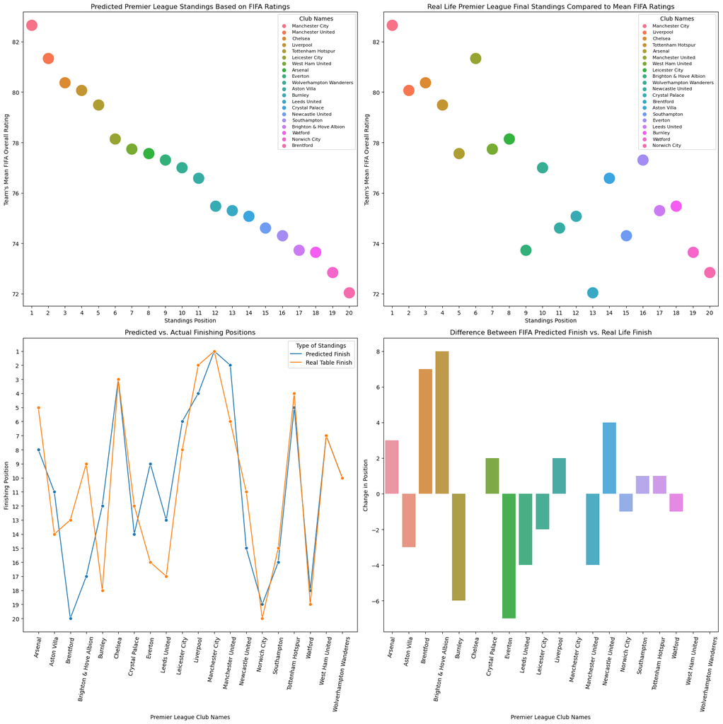

```python
fig, axs = plt.subplots(2, 2, figsize=(18,18))

sns.stripplot(data=prem_club_ratings, x='rank', y='overall', hue='club_name', ax=axs[0,0], size=20)
axs[0,0].legend(loc='upper right', title='Club Names', fontsize=8.0)
axs[0,0].set_xlabel('Standings Position')
axs[0,0].set_ylabel("Team's Mean FIFA Overall Rating")
axs[0,0].set_title("Predicted Premier League Standings Based on FIFA Ratings")



sns.stripplot(data=prem_club_ratings, x='Real Table Finish', y='overall', hue='club_name', ax=axs[0,1], size=20)
axs[0,1].legend(loc='upper right', title='Club Names', fontsize=8.0)
axs[0,1].set_xlabel('Standings Position')
axs[0,1].set_ylabel("Team's Mean FIFA Overall Rating")
axs[0,1].set_title("Real Life Premier League Final Standings Compared to Mean FIFA Ratings")

sns.barplot(data=prem_club_ratings, x='club_name', y='Difference in Predicted Finish', ax=axs[1,1])
axs[1,1].tick_params(axis='x', labelrotation=80)
axs[1,1].set_xlabel('Premier League Club Names')
axs[1,1].set_ylabel("Change in Position")
axs[1,1].set_title("Difference Between FIFA Predicted Finish vs. Real Life Finish")

prem_club_ratings = prem_club_ratings.rename(columns={'rank': 'Predicted Finish'})
prem_club_ratings = prem_club_ratings.loc[:,['club_name', 'Predicted Finish', 'Real Table Finish']]
melted_prem = prem_club_ratings.melt(id_vars='club_name', var_name='Type', value_name='Position')

sns.lineplot(x='club_name', y='Position', hue='Type', marker='o', data=melted_prem, ax=axs[1,0])

ticks = range(1,21)
tick_labels = [str(int(tick)) for tick in ticks]
axs[1,0].set_yticks(ticks, tick_labels)
axs[1,0].set_xlabel('Premier League Club Names')
axs[1,0].tick_params(axis='x', labelrotation=80)
axs[1,0].invert_yaxis()
axs[1,0].set_ylabel('Finishing Position')
axs[1,0].set_title('Predicted vs. Actual Finishing Positions')
axs[1,0].legend(title='Type of Standings')


plt.tight_layout()
plt.show()
```

### German League (Bundesliga)

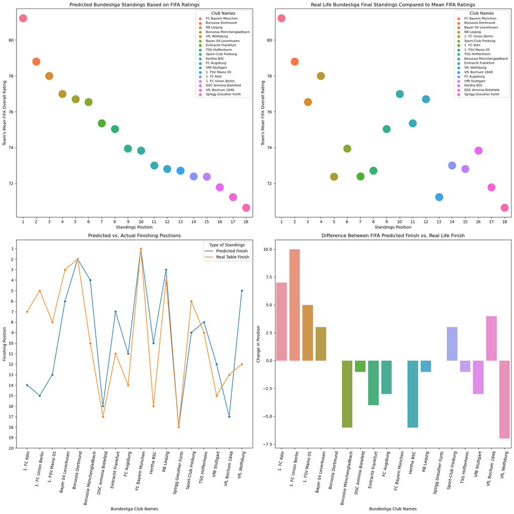

```python
fig, axs = plt.subplots(2, 2, figsize=(18,18))

sns.stripplot(data=bundesliga_club_ratings, x='rank', y='overall', hue='club_name', ax=axs[0,0], size=20)
axs[0,0].legend(loc='upper right', title='Club Names', fontsize=8.0)
axs[0,0].set_xlabel('Standings Position')
axs[0,0].set_ylabel("Team's Mean FIFA Overall Rating")
axs[0,0].set_title("Predicted Bundesliga Standings Based on FIFA Ratings")



sns.stripplot(data=bundesliga_club_ratings, x='Real Table Finish', y='overall', hue='club_name', ax=axs[0,1], size=20)
axs[0,1].legend(loc='upper right', title='Club Names', fontsize=8.0)
axs[0,1].set_xlabel('Standings Position')
axs[0,1].set_ylabel("Team's Mean FIFA Overall Rating")
axs[0,1].set_title("Real Life Bundesliga Final Standings Compared to Mean FIFA Ratings")

sns.barplot(data=bundesliga_club_ratings, x='club_name', y='Difference in Predicted Finish', ax=axs[1,1])
axs[1,1].tick_params(axis='x', labelrotation=80)
axs[1,1].set_xlabel('Bundesliga Club Names')
axs[1,1].set_ylabel("Change in Position")
axs[1,1].set_title("Difference Between FIFA Predicted Finish vs. Real Life Finish")

bundesliga_club_ratings = bundesliga_club_ratings.rename(columns={'rank': 'Predicted Finish'})
bundesliga_club_ratings = bundesliga_club_ratings.loc[:,['club_name', 'Predicted Finish', 'Real Table Finish']]
melted_bundesliga = bundesliga_club_ratings.melt(id_vars='club_name', var_name='Type', value_name='Position')

sns.lineplot(x='club_name', y='Position', hue='Type', marker='o', data=melted_bundesliga, ax=axs[1,0])

ticks = range(1,21)
tick_labels = [str(int(tick)) for tick in ticks]
axs[1,0].set_yticks(ticks, tick_labels)
axs[1,0].set_xlabel('Bundesliga Club Names')
axs[1,0].tick_params(axis='x', labelrotation=80)
axs[1,0].invert_yaxis()
axs[1,0].set_ylabel('Finishing Position')
axs[1,0].set_title('Predicted vs. Actual Finishing Positions')
axs[1,0].legend(title='Type of Standings')


plt.tight_layout()
plt.show()
```

### Spanish League (La Liga)

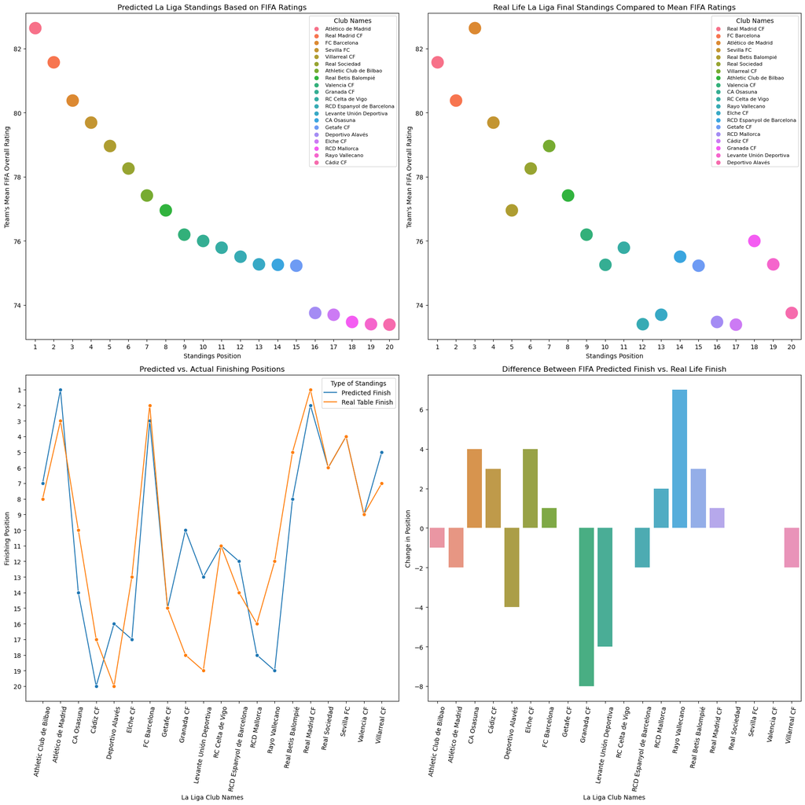

```python
fig, axs = plt.subplots(2, 2, figsize=(18,18))

sns.stripplot(data=laliga_club_ratings, x='rank', y='overall', hue='club_name', ax=axs[0,0], size=20)
axs[0,0].legend(loc='upper right', title='Club Names', fontsize=8.0)
axs[0,0].set_xlabel('Standings Position')
axs[0,0].set_ylabel("Team's Mean FIFA Overall Rating")
axs[0,0].set_title("Predicted La Liga Standings Based on FIFA Ratings")



sns.stripplot(data=laliga_club_ratings, x='Real Table Finish', y='overall', hue='club_name', ax=axs[0,1], size=20)
axs[0,1].legend(loc='upper right', title='Club Names', fontsize=8.0)
axs[0,1].set_xlabel('Standings Position')
axs[0,1].set_ylabel("Team's Mean FIFA Overall Rating")
axs[0,1].set_title("Real Life La Liga Final Standings Compared to Mean FIFA Ratings")

sns.barplot(data=laliga_club_ratings, x='club_name', y='Difference in Predicted Finish', ax=axs[1,1])
axs[1,1].tick_params(axis='x', labelrotation=80)
axs[1,1].set_xlabel('La Liga Club Names')
axs[1,1].set_ylabel("Change in Position")
axs[1,1].set_title("Difference Between FIFA Predicted Finish vs. Real Life Finish")

laliga_club_ratings = laliga_club_ratings.rename(columns={'rank': 'Predicted Finish'})
laliga_club_ratings = laliga_club_ratings.loc[:,['club_name', 'Predicted Finish', 'Real Table Finish']]
melted_laliga = laliga_club_ratings.melt(id_vars='club_name', var_name='Type', value_name='Position')

sns.lineplot(x='club_name', y='Position', hue='Type', marker='o', data=melted_laliga, ax=axs[1,0])

ticks = range(1,21)
tick_labels = [str(int(tick)) for tick in ticks]
axs[1,0].set_yticks(ticks, tick_labels)
axs[1,0].set_xlabel('La Liga Club Names')
axs[1,0].tick_params(axis='x', labelrotation=80)
axs[1,0].invert_yaxis()
axs[1,0].set_ylabel('Finishing Position')
axs[1,0].set_title('Predicted vs. Actual Finishing Positions')
axs[1,0].legend(title='Type of Standings')


plt.tight_layout()
plt.show()
```

### Italian League (Serie A)

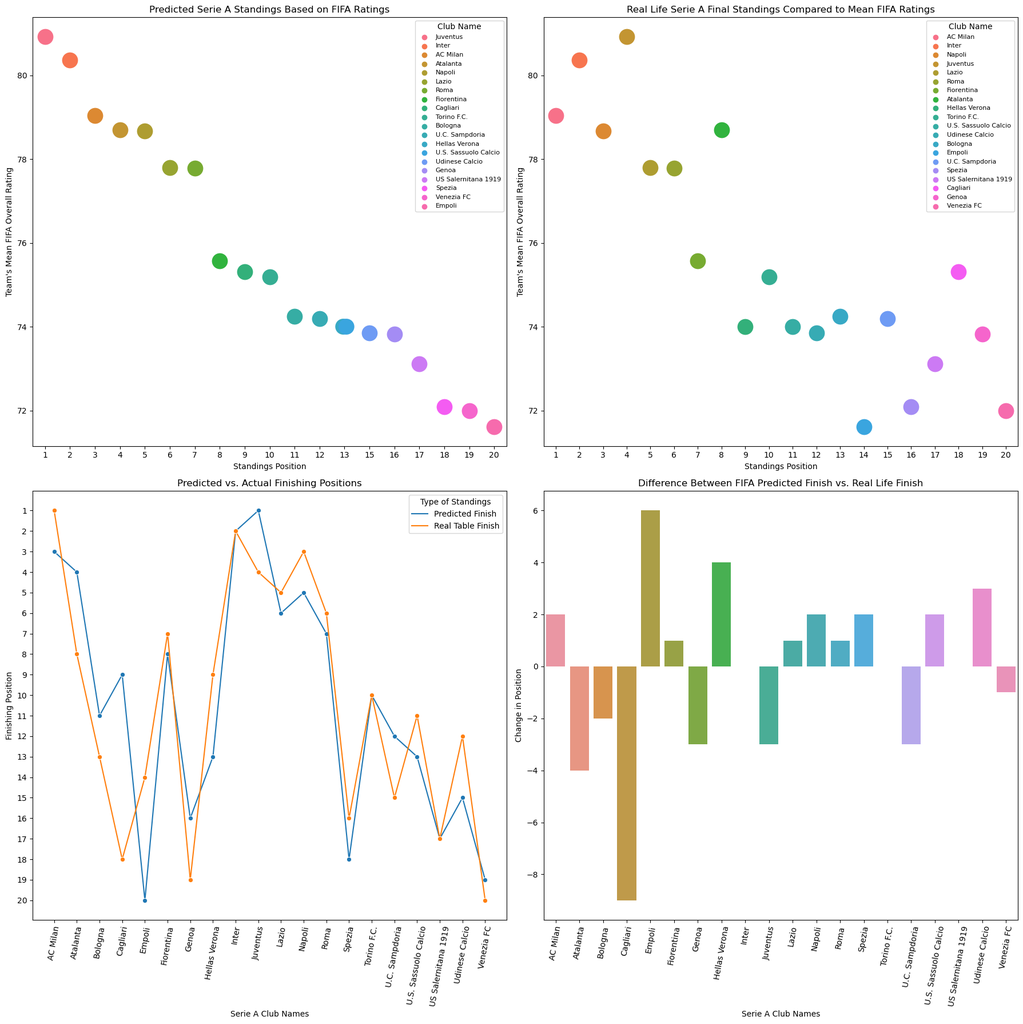

```python
fig, axs = plt.subplots(2, 2, figsize=(18,18))

sns.stripplot(data=seriea_club_ratings, x='rank', y='overall', hue='club_name', ax=axs[0,0], size=20)
axs[0,0].legend(loc='upper right', title='Club Name', fontsize=8.0)
axs[0,0].set_xlabel('Standings Position')
axs[0,0].set_ylabel("Team's Mean FIFA Overall Rating")
axs[0,0].set_title("Predicted Serie A Standings Based on FIFA Ratings")

sns.stripplot(data=seriea_club_ratings, x='Real Table Finish', y='overall', hue='club_name', ax=axs[0,1], size=20)
axs[0,1].legend(loc='upper right', title='Club Name', fontsize=8.0)
axs[0,1].set_xlabel('Standings Position')
axs[0,1].set_ylabel("Team's Mean FIFA Overall Rating")
axs[0,1].set_title("Real Life Serie A Final Standings Compared to Mean FIFA Ratings")

sns.barplot(data=seriea_club_ratings, x='club_name', y='Difference in Predicted Finish', ax=axs[1,1])
axs[1,1].tick_params(axis='x', labelrotation=80)
axs[1,1].set_xlabel('Serie A Club Names')
axs[1,1].set_ylabel("Change in Position")
axs[1,1].set_title("Difference Between FIFA Predicted Finish vs. Real Life Finish")

seriea_club_ratings = seriea_club_ratings.rename(columns={'rank': 'Predicted Finish'})
seriea_club_ratings = seriea_club_ratings.loc[:,['club_name', 'Predicted Finish', 'Real Table Finish']]
melted_seriea = seriea_club_ratings.melt(id_vars='club_name', var_name='Type', value_name='Position')

sns.lineplot(x='club_name', y='Position', hue='Type', marker='o', data=melted_seriea, ax=axs[1,0])

ticks = range(1,21)
tick_labels = [str(int(tick)) for tick in ticks]
axs[1,0].set_yticks(ticks, tick_labels)
axs[1,0].set_xlabel('Serie A Club Names')
axs[1,0].tick_params(axis='x', labelrotation=80)
axs[1,0].invert_yaxis()
axs[1,0].set_ylabel('Finishing Position')
axs[1,0].set_title('Predicted vs. Actual Finishing Positions')
axs[1,0].legend(title='Type of Standings')


plt.tight_layout()
plt.show()
```

### French League (Ligue 1)

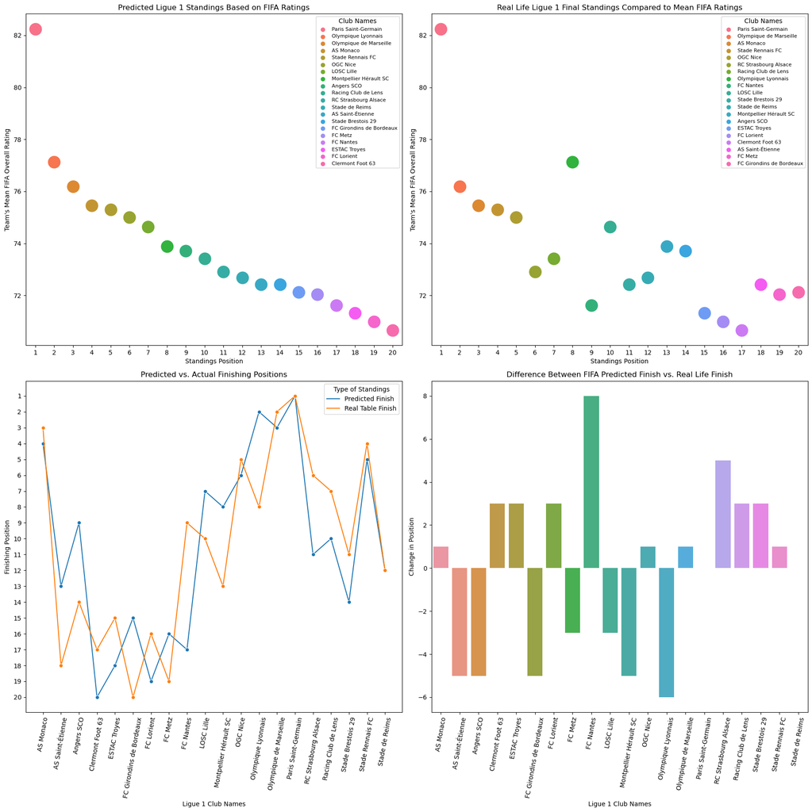

```python
fig, axs = plt.subplots(2, 2, figsize=(18,18))

sns.stripplot(data=ligue1_club_ratings, x='rank', y='overall', hue='club_name', ax=axs[0,0], size=20)
axs[0,0].legend(loc='upper right', title='Club Names', fontsize=8.0)
axs[0,0].set_xlabel('Standings Position')
axs[0,0].set_ylabel("Team's Mean FIFA Overall Rating")
axs[0,0].set_title("Predicted Ligue 1 Standings Based on FIFA Ratings")



sns.stripplot(data=ligue1_club_ratings, x='Real Table Finish', y='overall', hue='club_name', ax=axs[0,1], size=20)
axs[0,1].legend(loc='upper right', title='Club Names', fontsize=8.0)
axs[0,1].set_xlabel('Standings Position')
axs[0,1].set_ylabel("Team's Mean FIFA Overall Rating")
axs[0,1].set_title("Real Life Ligue 1 Final Standings Compared to Mean FIFA Ratings")

sns.barplot(data=ligue1_club_ratings, x='club_name', y='Difference in Predicted Finish', ax=axs[1,1])
axs[1,1].tick_params(axis='x', labelrotation=80)
axs[1,1].set_xlabel('Ligue 1 Club Names')
axs[1,1].set_ylabel("Change in Position")
axs[1,1].set_title("Difference Between FIFA Predicted Finish vs. Real Life Finish")

ligue1_club_ratings = ligue1_club_ratings.rename(columns={'rank': 'Predicted Finish'})
ligue1_club_ratings = ligue1_club_ratings.loc[:,['club_name', 'Predicted Finish', 'Real Table Finish']]
melted_ligue1 = ligue1_club_ratings.melt(id_vars='club_name', var_name='Type', value_name='Position')

sns.lineplot(x='club_name', y='Position', hue='Type', marker='o', data=melted_ligue1, ax=axs[1,0])

ticks = range(1,21)
tick_labels = [str(int(tick)) for tick in ticks]
axs[1,0].set_yticks(ticks, tick_labels)
axs[1,0].set_xlabel('Ligue 1 Club Names')
axs[1,0].tick_params(axis='x', labelrotation=80)
axs[1,0].invert_yaxis()
axs[1,0].set_ylabel('Finishing Position')
axs[1,0].set_title('Predicted vs. Actual Finishing Positions')
axs[1,0].legend(title='Type of Standings')


plt.tight_layout()
plt.show()
```

### Accuracy Between Leagues

- With all of this data now processed and visualized, I wanted to get a sort of "final answer" to my question. I wanted to see on average how far off EA is ranking teams in each different league, and then compare them to see in this version of the game (FIFA 22), which league were they the worst at predicting

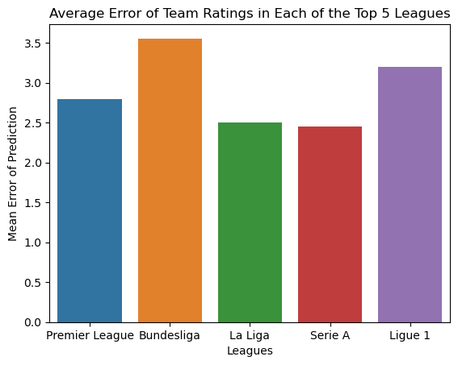

```python
leagues = ['Premier League', 'Bundesliga', 'La Liga', 'Serie A', 'Ligue 1']
league_error = [prem_avg_error, bundesliga_avg_error, laliga_avg_error, seriea_avg_error, ligue1_avg_error]

avg_league_error = pd.DataFrame({'Leagues':leagues, 'Mean Error of Prediction':league_error})

#fig, axs = plt.subplots(figsize=(5,10))

sns.barplot(data=avg_league_error, x='Leagues', y='Mean Error of Prediction', dodge=False)
plt.title('Average Error of Team Ratings in Each of the Top 5 Leagues')

plt.show()
```

As you can see from this chart, EA Sports averages anywhere from around 2.5-3.5 places off for teams in their rankings. This number is honestly lower than I expected, but I think these visualizations actually tell a bigger story about their system. The chart above also shows that they were the most inaccurate in the Bundesliga and most accurate in the Serie A. This is a suprising result for me as EA Sports are much more heavily partnered with the Premier League (as of this year, EA Sports is one of their main sponsors, but have been on a smaller scale for a long time as well) so I assumed they would have more data available to them to make more accurate rankings.

## Summary

Looking at the most extreme ends of the rankings, EA Sports correctly predicted the champions 3/5 times and the last-placed teams only 1/5 times, showing much more consistency at guessing the more watched/better teams, but not as much for teams with less recognition. I think that my visualizations prove that EA Sports must spend more time doing research on non-top teams as in most of my graphs, after the top 5/6 teams, there is much more variability in the predicted/real life results. This is probably partly due to the fact that all of these leagues are part of tiered systems, where teams can get relegated and promoted each year, but a lot of this inaccuracy is still falling with teams who have been in the league for multiple years. Predicting sport results is no easy feat, but for a company who has to spend the entire year, watching and collecting data in order to update their game with new ratings and rewards based on real-life results, I would expect more accuracy from these results.